# Ian's_Copy_of_MachineLearningAssignment1

## Importing Data

```python
from google.colab import drive
drive.mount('/content/drive')
```

```python
# Import File using Pandas
import pandas as pd

# Define the path to the Excel file
file_path = '/content/drive/MyDrive/BAX 452/fundamentals.csv'

# Read the Excel file
df = pd.read_csv(file_path)

# Display the first few rows of the DataFrame
print(df.head())
```

```
   Unnamed: 0 Ticker Symbol Period Ending  Accounts Payable  \
0           0           AAL    2012-12-31      3.068000e+09
1           1           AAL    2013-12-31      4.975000e+09
2           2           AAL    2014-12-31      4.668000e+09
3           3           AAL    2015-12-31      5.102000e+09
4           4           AAP    2012-12-29      2.409453e+09

   Accounts Receivable  Add'l income/expense items  After Tax ROE  \
0         -222000000.0               -1.961000e+09           23.0
1          -93000000.0               -2.723000e+09           67.0
2         -160000000.0               -1.500000e+08          143.0
3          352000000.0               -7.080000e+08          135.0
4          -89482000.0                6.000000e+05           32.0

   Capital Expenditures  Capital Surplus  Cash Ratio  ...  \
```

[output cut: 28 more lines]

# **#1. Data Exploration and Visualization: Explore the “fundamentals.csv”. Include any other plots you find interesting (10 pts)**

## Heatmap of Financial Columns

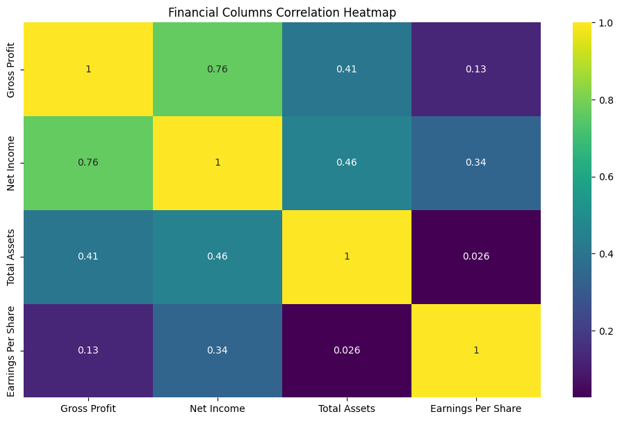

```python
# Exploratory Data Analysis

#Heatmap - EDA1
import pandas as pd
import seaborn as sns
import matplotlib.pyplot as plt

# Choosing the financial columns for the heatmap
fin_col = ['Gross Profit', 'Net Income', 'Total Assets', 'Earnings Per Share']

# Plotting the heatmap to see the correlation between financial variables
plt.figure(figsize=(12, 7))
sns.heatmap(df[fin_col].corr(), annot=True, cmap='viridis')
plt.title('Financial Columns Correlation Heatmap')
plt.show()
```

Insights :

- There is a significant positive correlation of 0.76 between Gross Profit and Net Income. This correlation aligns with the general expectation that a company's profits usually increase with rising income; however, the relationship is not perfect, suggesting that there can be considerable variations in the additional expenses incurred to generate higher incomes.
- The correlation between Gross Profit and Total Assets is moderately positive at 0.41, and a similar correlation of 0.46 is observed between Net Income and Total Assets. These correlations indicate a somewhat positive relationship between a company's total assets and its gross profit and net income. The closeness of these correlation values is logical since both Gross Profit and Net Income are different measures of a company's revenue.
- Regarding the correlation between Total Assets and Earnings per Share, it is very weak, standing at just 0.026. This implies that it's not feasible to draw any substantial conclusions about how a company's total assets might impact its earnings per share. This is understandable, considering that earnings are influenced more by market performance than by the accumulation of assets over time.

# Analysis of Total Revenue Over Time

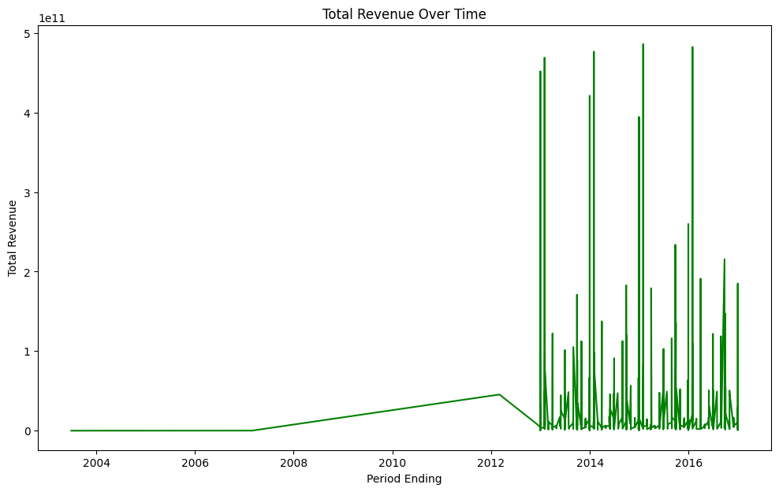

```python
#EDA2

# To see behaviour over time, I used datetime
df['Period Ending'] = pd.to_datetime(df['Period Ending'])

#Sort Date Values for a clearer graph
df.sort_values('Period Ending', inplace=True)

# Plot Total Revenue vs Period Ending(datatime format)
plt.figure(figsize=(12, 7))
plt.plot(df['Period Ending'], df['Total Revenue'], label='Total Revenue', color='green')
plt.xlabel('Period Ending')
plt.ylabel('Total Revenue')
plt.title('Total Revenue Over Time')
plt.show()
```

Insights:

- From 2004 to 2006, the revenue appears stable and consistently low, with no significant fluctuations observed during this period.
- In contrast, the period from 2014 to 2016 is marked by considerable volatility in revenue. There are noticeable and rapid fluctuations, with revenue frequently rising and then declining. This pattern continues throughout these years. The graph also shows that there is a wide variation in annual revenues among different companies, which aligns with expectations. This visualization effectively confirms our initial thoughts about revenue trends over time for these companies, acting as a data validation tool. The smoothness of the plot from 2004 to 2006 suggests that this period might warrant further investigation to understand the underlying reasons for such stability.

# Distribution of Gross Profit in terms of Billions of Dollars

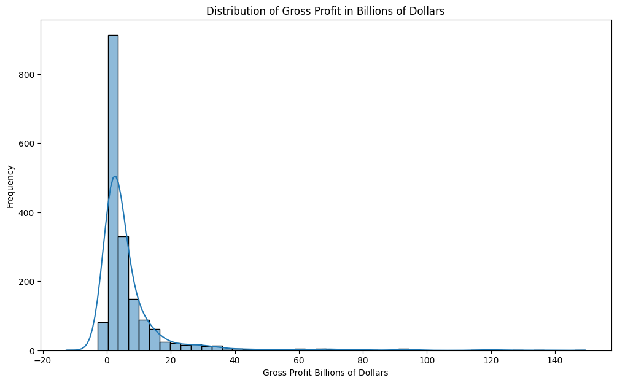

```python
#EDA3

# Histogram of Gross Profit , maintaining the same plot size 12,7
plt.figure(figsize=(12, 7))

# Dividing the Gross Profit by 1e9 to convert to billion , KDE- Kernel Density Estimate
sns.histplot(df['Gross Profit'] / 1e9, bins=50, kde=True)
plt.title('Distribution of Gross Profit in Billions of Dollars')
plt.xlabel('Gross Profit Billions of Dollars')
plt.ylabel('Frequency')
plt.show()
```

Insights:

- Most data points cluster around the lower end of the spectrum, suggesting that the gross profit for most companies is roughly between $$0 and $3.3B.
- Data is right skewed - a totally normal distribution for gross profits would not make sense as that would imply there are a number of businesses operate with substantial losses, which we do not see in the real world.
- There are only a handful of companies that make more than $37B.

# Using Stacked Bar Chart to analyze Accounts Payable and Receivable Over the Year

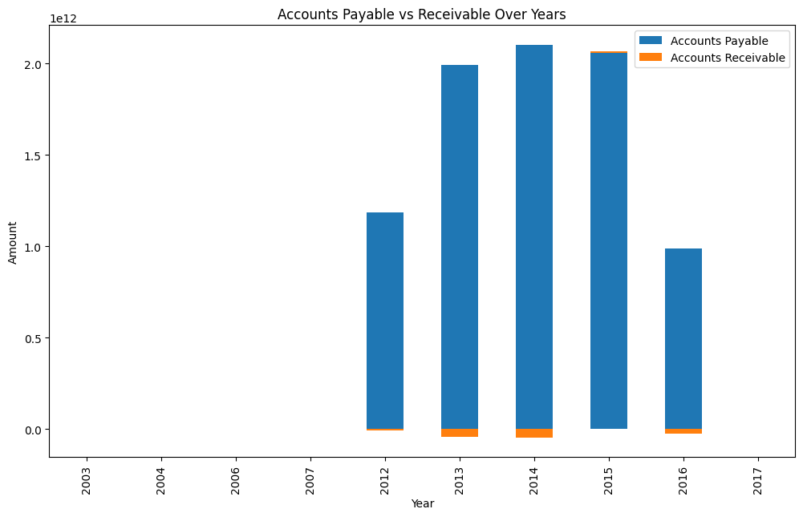

```python
#EDA 4
# To see behaviour over time, I used datetime , also specify format
df['Period Ending'] = pd.to_datetime(df['Period Ending'], format='%d-%m-%Y')

# Extract year
df['Year'] = df['Period Ending'].dt.year

# Group by Year and sum Accounts Payable and Accounts Receivable
grouped_df = df.groupby('Year')[['Accounts Payable', 'Accounts Receivable']].sum()

# Plot the results - Stacked Bar chart
grouped_df.plot(kind='bar', stacked=True, figsize=(12, 7))
plt.title('Accounts Payable vs Receivable Over Years')
plt.xlabel('Year')
plt.ylabel('Amount')
plt.show()
```

Insights :

# Violin Plot - Earnings Before Interest and Tax

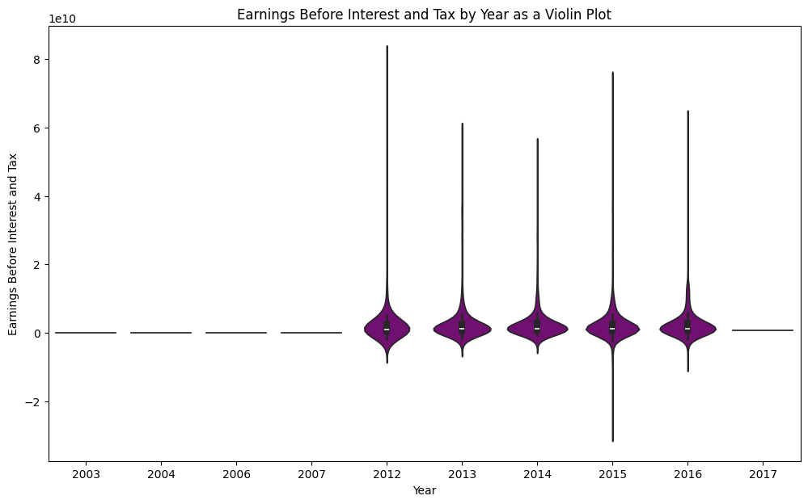

```python
#EDA 5
# Converting Period Ending to datetime and extract the year , also specify format
df['Period Ending'] = pd.to_datetime(df['Period Ending'], format='%d-%m-%Y')
df['Year'] = df['Period Ending'].dt.year

# Violin plot for Earnings Before Interest and Tax by Year
plt.figure(figsize=(12, 7))
sns.violinplot(x='Year', y='Earnings Before Interest and Tax', data=df, color='purple')
plt.title('Earnings Before Interest and Tax by Year as a Violin Plot')
plt.xlabel('Year')
plt.ylabel('Earnings Before Interest and Tax')
plt.show()
```

# Graph of Total Equity and Total Liabilities Per Year

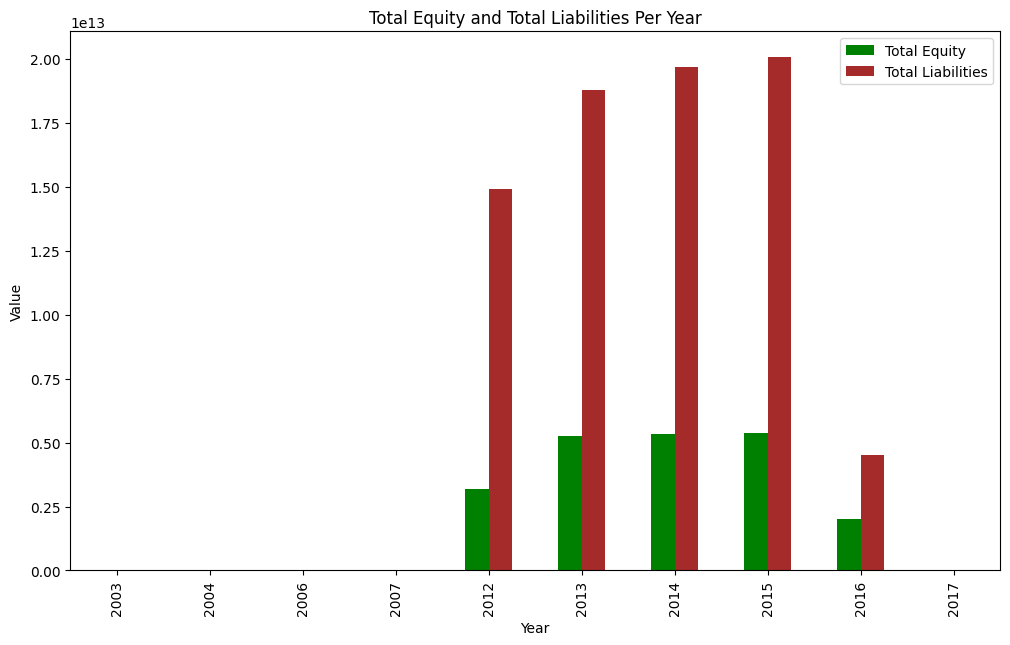

```python
#EDA 6
# Converting Period Ending to datetime and extract the year
df['Year'] = df['Period Ending'].dt.year
equity_liabilities_by_year = df.groupby('Year')[['Total Equity', 'Total Liabilities']].sum()

# Colors
colors = ["green", "brown"]

equity_liabilities_by_year.plot(kind='bar', figsize=(12, 7), color=colors)
plt.xlabel('Year')
plt.ylabel('Value')
plt.title('Total Equity and Total Liabilities Per Year')
plt.show()
```

Insights :

- 2012: Total Liabilities are much larger than the Total Equity. This indicates companies have taken on more debt relative to its equity. This supports our findings in the stacked bar chart with companies over leveraging themselves.
- 2013-2015: In these consecutive years, both Total Equity and Total Liabilities increase. This trend suggests continued reliance on debt financing.
- 2016: Reduction in both Total Equity and Total Liabilities

# **2. Linear Regression Model Development: Create linear regression to predict Estimated Shares Outstanding. Explain your model (15pts)**

```
                                 OLS Regression Results
========================================================================================
Dep. Variable:     Estimated Shares Outstanding   R-squared:                       0.854
Model:                                      OLS   Adj. R-squared:                  0.846
Method:                           Least Squares   F-statistic:                     98.40
Date:                          Thu, 18 Jan 2024   Prob (F-statistic):               0.00
Time:                                  10:38:50   Log-Likelihood:                -27507.
No. Observations:                          1299   AIC:                         5.516e+04
Df Residuals:                              1225   BIC:                         5.554e+04
Df Model:                                    73
Covariance Type:                      nonrobust
=======================================================================================================================
                                                          coef    std err          t      P>|t|      [0.025      0.975]
-----------------------------------------------------------------------------------------------------------------------
const                                                7.312e+08      1e+09      0.729      0.466   -1.24e+09     2.7e+09
Accounts Payable                                     -183.9454    238.959     -0.770      0.442    -652.760     284.869
Accounts Receivable                                    -0.0722      0.057     -1.274      0.203      -0.183       0.039
Add'l income/expense items                              0.0361      0.057      0.635      0.525      -0.075       0.148
After Tax ROE                                       -6.663e+05      5e+05     -1.332      0.183   -1.65e+06    3.15e+05
Capital Expenditures                                    0.9122      2.396      0.381      0.704      -3.789       5.614
Capital Surplus                                         0.0149      0.009      1.631      0.103      -0.003       0.033
Cash Ratio                                           6.866e+05   3.83e+05      1.793      0.073   -6.45e+04    1.44e+06
Cash and Cash Equivalents                              -1.2388      0.617     -2.008      0.045      -2.449      -0.029
Changes in Inventories                                 -0.0876      0.060     -1.456      0.146      -0.206       0.030
Common Stocks                                          -0.0014      0.010     -0.143      0.886      -0.020       0.018
Cost of Revenue                                     -1348.2780   1846.842     -0.730      0.466   -4971.601    2275.045
Current Ratio                                       -2.044e+05   2.94e+05     -0.695      0.487   -7.82e+05    3.73e+05
Deferred Asset Charges                                 -0.0585      0.989     -0.059      0.953      -1.999       1.882
Deferred Liability Charges                              0.0094      0.099      0.095      0.925      -0.185       0.204
Depreciation                                           -0.0843      0.057     -1.488      0.137      -0.196       0.027
Earnings Before Interest and Tax                       22.5389     39.533      0.570      0.569     -55.022     100.100
Earnings Before Tax                                   -22.8602     39.533     -0.578      0.563    -100.420      54.699
Effect of Exchange Rate                                -0.0233      0.166     -0.141      0.888      -0.348       0.302
Equity Earnings/Loss Unconsolidated Subsidiary          0.1119      0.082      1.371      0.171      -0.048       0.272
Fixed Assets                                           -0.0572      0.989     -0.058      0.954      -1.998       1.883
Goodwill                                               -0.0642      0.989     -0.065      0.948      -2.005       1.876
Gross Margin                                        -1.512e+05   7.36e+05     -0.205      0.837    -1.6e+06    1.29e+06
Gross Profit                                        -1348.2810   1846.842     -0.730      0.466   -4971.605    2275.043
Income Tax                                              0.1562      0.067      2.342      0.019       0.025       0.287
Intangible Assets                                      -0.0544      0.989     -0.055      0.956      -1.995       1.886
```

[output cut: 46 more lines]

```
Total Revenue                                        1348.2772   1846.842      0.730      0.466   -2275.046    4971.601
Treasury Stock                                         -0.0074      0.009     -0.807      0.420      -0.025       0.011
For Year                                            -2.385e+05   4.97e+05     -0.480      0.631   -1.21e+06    7.36e+05
Earnings Per Share                                  -3.087e+07   2.81e+06    -10.983      0.000   -3.64e+07   -2.54e+07
==============================================================================
Omnibus:                     1262.725   Durbin-Watson:                   2.038
Prob(Omnibus):                  0.000   Jarque-Bera (JB):           238833.442
Skew:                           3.999   Prob(JB):                         0.00
Kurtosis:                      68.944   Cond. No.                     1.17e+16
==============================================================================

Notes:
[1] Standard Errors assume that the covariance matrix of the errors is correctly specified.
[2] The condition number is large, 1.17e+16. This might indicate that there are
strong multicollinearity or other numerical problems.
```

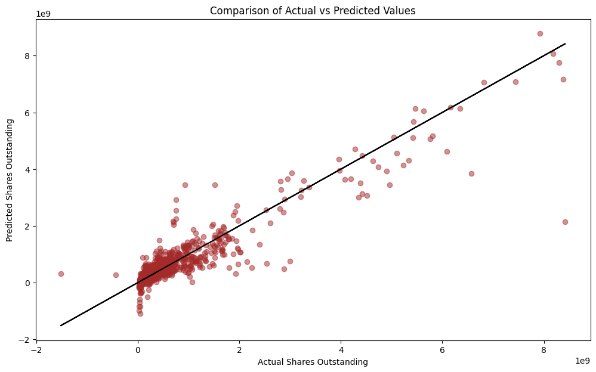

```python
##Linear Regression Model Development -  Create linear regression to predict Estimated Shares Outstanding. Explain your model.
import pandas as pd
import statsmodels.api as sm
import matplotlib.pyplot as plt

# Drop rows with missing values
df.dropna(inplace=True)

# Define Xreg and Yreg Xreg does not contain Estimates Shares Outstanding , Ticker Symbol , Period Ending
X_lreg = [
  'Accounts Payable', 'Accounts Receivable', 'Add\'l income/expense items',
  'After Tax ROE', 'Capital Expenditures', 'Capital Surplus', 'Cash Ratio',
  'Cash and Cash Equivalents', 'Changes in Inventories', 'Common Stocks',
  'Cost of Revenue', 'Current Ratio', 'Deferred Asset Charges',
  'Deferred Liability Charges', 'Depreciation', 'Earnings Before Interest and Tax',
  'Earnings Before Tax', 'Effect of Exchange Rate', 'Equity Earnings/Loss Unconsolidated Subsidiary',
  'Fixed Assets', 'Goodwill', 'Gross Margin', 'Gross Profit', 'Income Tax',
  'Intangible Assets', 'Interest Expense', 'Inventory', 'Investments', 'Liabilities',
  'Long-Term Debt', 'Long-Term Investments', 'Minority Interest', 'Misc. Stocks',
  'Net Borrowings', 'Net Cash Flow', 'Net Cash Flow-Operating', 'Net Cash Flows-Financing',
  'Net Cash Flows-Investing', 'Net Income', 'Net Income Adjustments',
  'Net Income Applicable to Common Shareholders', 'Net Income-Cont. Operations',
  'Net Receivables', 'Non-Recurring Items', 'Operating Income', 'Operating Margin',
  'Other Assets', 'Other Current Assets', 'Other Current Liabilities', 'Other Equity',
  'Other Financing Activities', 'Other Investing Activities', 'Other Liabilities',
  'Other Operating Activities', 'Other Operating Items', 'Pre-Tax Margin', 'Pre-Tax ROE',
  'Profit Margin', 'Quick Ratio', 'Research and Development', 'Retained Earnings',
  'Sale and Purchase of Stock', 'Sales, General and Admin.', 'Short-Term Debt / Current Portion of Long-Term Debt',
  'Short-Term Investments', 'Total Assets', 'Total Current Assets', 'Total Current Liabilities',
  'Total Equity', 'Total Liabilities', 'Total Liabilities & Equity', 'Total Revenue',
  'Treasury Stock', 'For Year', 'Earnings Per Share'
]
Y_lreg = 'Estimated Shares Outstanding'

# Defining variables
X = df[X_lreg]
y = df[Y_lreg]

# Add a constant for the intercept term
X = sm.add_constant(X)

# Create and train the model
model_2 = sm.OLS(y, X).fit()

# Print summary statistics of the model
print(model_2.summary())

# Predict
y_pred = model_2.predict(X)

# Plotting
plt.figure(figsize=(12, 7))
plt.scatter(y, y_pred, alpha=0.5,color='brown')
plt.plot(y, y, color='black')
plt.title('Comparison of Actual vs Predicted Values')
plt.xlabel('Actual Shares Outstanding')
plt.ylabel('Predicted Shares Outstanding')
plt.show()
```

Insights from Regression model

- The model exhibits an R-squared value of 0.854, which implies that about 85.4% of the variation in the dependent variable (Estimated Shares Outstanding) is accounted for by the independent variables included in the model. This indicates a robust fit.
- However, the model also signals the presence of multicollinearity, suggesting that some of the independent variables may be closely interrelated. This can impact the reliability of the coefficient estimates, as it becomes difficult to isolate the effect of each independent variable.

Observations from the Graph:

- A significant number of data points cluster around the black line, which symbolizes a one-to-one relationship. This indicates that the model's predictions are in proportion to the actual values for a substantial portion of the observations.

# **3. Multicollinearity in Linear Regression: Explain how multicollinearity can affect the interpretation of linear regression model coefficients(Written) (10 points)**

These are some ways Multicollinearity affects the interpretation of linear regression model coefficients - with repect to my model

What is Multicollinearity - It refers to a condition in regression analysis where two or more independent variables are highly correlated with each other.

- High correlation among independent variables causes instability in the coefficient estimates of the model, potentially leading to skewed results.
- Multicollinearity typically results in inflated standard errors for the coefficients. This inflation leads to broader confidence intervals and higher p-values, which complicates the identification of statistically significant variables. For example, even if Inventory is a crucial variable in the model, its significance might be obscured by inaccurate p-value calculations caused by multicollinearity, leading to incorrect conclusions.
- Additionally, multicollinearity makes it challenging to distinguish the individual impact of correlated variables. For instance, if Total Assets and Total Liabilities are highly correlated, the model will struggle to isolate the effect of each on Estimated Shares Outstanding, resulting in incorrect interpretations.
- Multicollinearity can also cause coefficients to have counterintuitive signs. A variable that should theoretically have a positive effect might exhibit a negative coefficient, and vice versa, further complicating the interpretation of the model's results.

# **4. P-Value Analysis and Histogram: Create a histogram of the p-values. Is there any skewedness ? Provide your explanation(10 pts)**

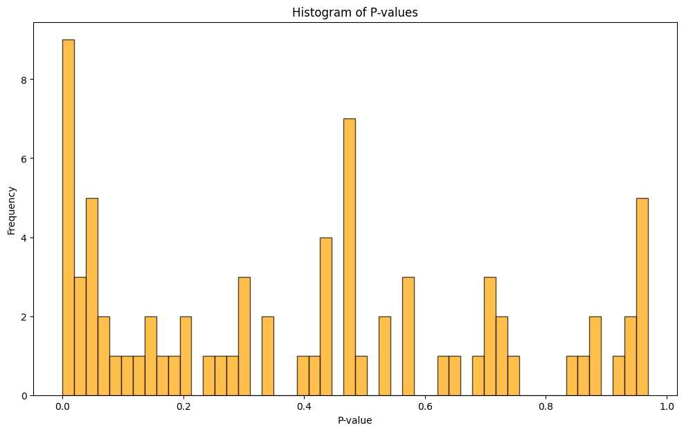

```
Skewness for all p-values: 0.3229820169397129
```

```python
import statsmodels.api as sm
from scipy.stats import skew

# Get the coefficients and p-values
coefficients = model_2.params
pvals = model_2.pvalues

import matplotlib.pyplot as plt

# Plot a histogram of p-values
plt.figure(figsize=(12,7))
plt.hist(pvals, bins=50, color='orange', edgecolor='black', alpha=0.7)
plt.title("Histogram of P-values")
plt.xlabel("P-value")
plt.ylabel("Frequency")
plt.show()

# Calculate and print the skewness for the flattened array of p-values
skewness_all = skew(pvals)
print(f"Skewness for all p-values: {skewness_all}")
```

```python
from scipy.stats import kstest

ks_statistic, ks_pvalue = kstest(pvals, 'uniform')

ks_statistic, ks_pvalue
```

```
(0.17887728615204268, 0.013414930411356968)
```

Skewness of the distribution of p-values is 0.3229. Skewness is a measure of the asymmetry of a probability distribution. Skewness always lies between 0 and 1.

Here's what the skewness value implies:

A skewness value of 0.3229 indicates a mild right-skew in the distribution of p-values. This suggests

- Most p-values returned are higher than the median value/ many coefficients are not statistically significant
- It could imply that multiple variables in the model are not contibuting to the model -i.e the model has multiple unessary variables
- This coincides with our regression output showing most variables as statistically insignificant

# **5. False Discovery Rate Control with BH Procedure: Given the p values you find, use the BH procedure to control the FDR with a q of 0.1. How many “true” discoveries do you estimate?(15 pts)**

```
Alpha: 0.0016866310609291062
Number of true discoveries: 7
```

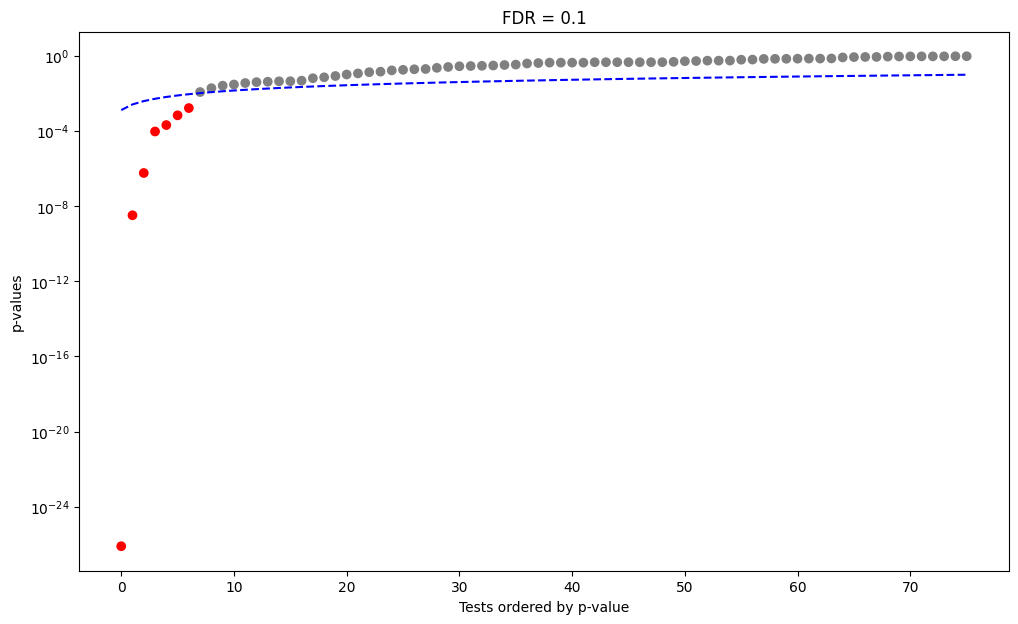

```python
#Using the code provided by professor
import numpy as np
import matplotlib.pyplot as plt

def fdr(pvals, q, plotit=False):
    # Remove NA values
    pvals = np.array(pvals)
    pvals = pvals[~np.isnan(pvals)]
    N = len(pvals)

    # Sort the p-values and calculate the FDR threshold
    sorted_pvals = np.sort(pvals)
    k = np.arange(1, N + 1)
    fdr_threshold = (q * k) / N

    # Find the last p-value that is below the FDR threshold
    below_threshold = sorted_pvals <= fdr_threshold
    max_index = np.max(np.where(below_threshold)) if np.any(below_threshold) else 0
    alpha = sorted_pvals[max_index]
    print(f"Alpha: {alpha}")

     # Count the number of true discoveries
    num_true_discoveries = np.sum(sorted_pvals <= alpha)
    print("Number of true discoveries:", num_true_discoveries)

    plt.figure(figsize=(12,7))

    # Optional plot
    if plotit:
      plt.scatter(range(N), sorted_pvals, c=np.where(sorted_pvals <= alpha, 'red', 'grey'), marker='o')
      plt.yscale('log')
      plt.plot(range(N), fdr_threshold, linestyle='--', color='blue')
      plt.xlabel("Tests ordered by p-value")
      plt.ylabel("p-values")
      plt.title(f"FDR = {q}")
      plt.show()


    return alpha

# Test the fdr function with an example - we substitute with the p values received in the previous step
plt.figure(figsize=(12,7))
np.random.seed(42)
#test_pvals = np.random.uniform(0, 1, 1000)
alpha_threshold = fdr(pvals, 0.1, plotit=True)
```

We estimate 7 True Discoveries for a BH procedure, for FDR of q=0.1

# **6. Sensitivity Analysis of FDR Control: If you apply the BH procedure at different q values, how do the results change? What does this tell you about the robustness of your significant variables? (10 pts)**

```
Alpha: 0.0006898272042557359
Number of true discoveries: 6
```

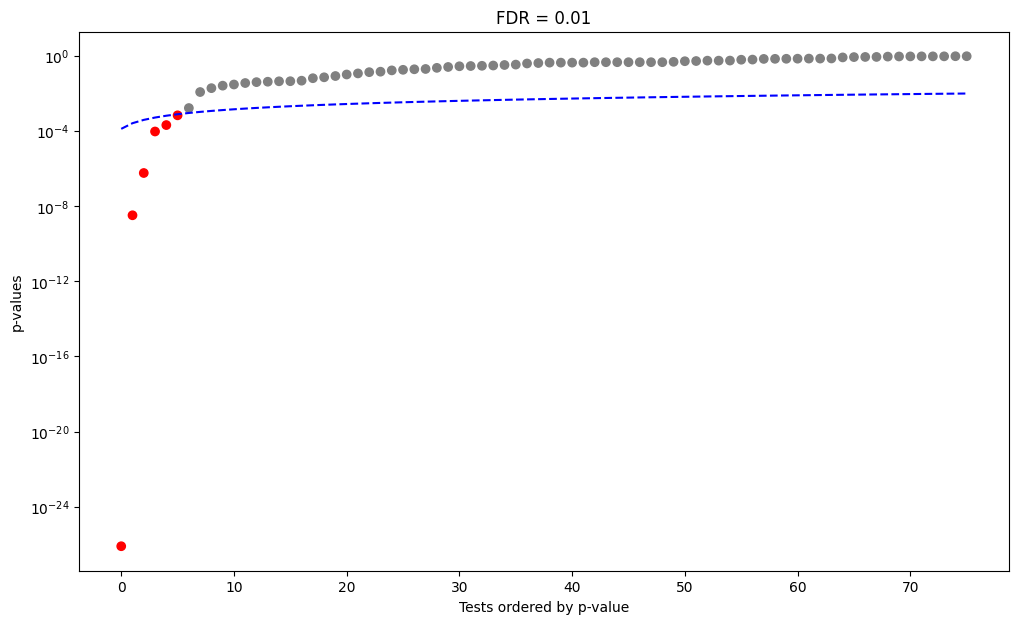

```
Alpha: 0.0016866310609291062
Number of true discoveries: 7
```

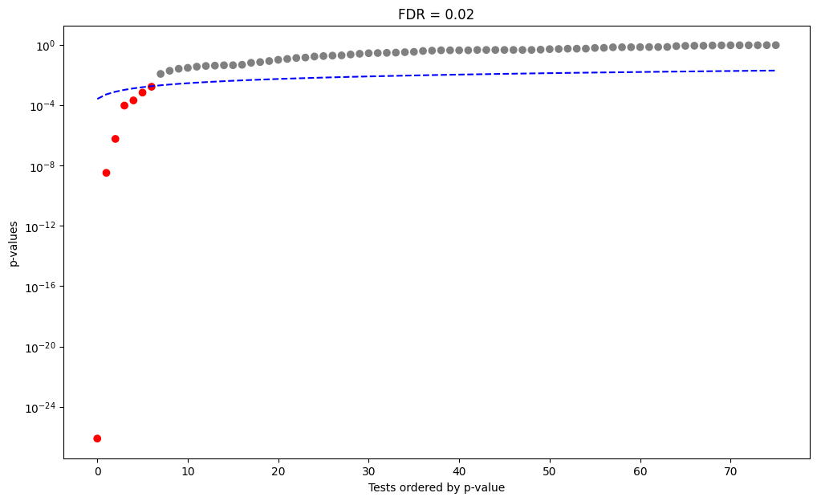

```
Alpha: 0.0016866310609291062
Number of true discoveries: 7
```

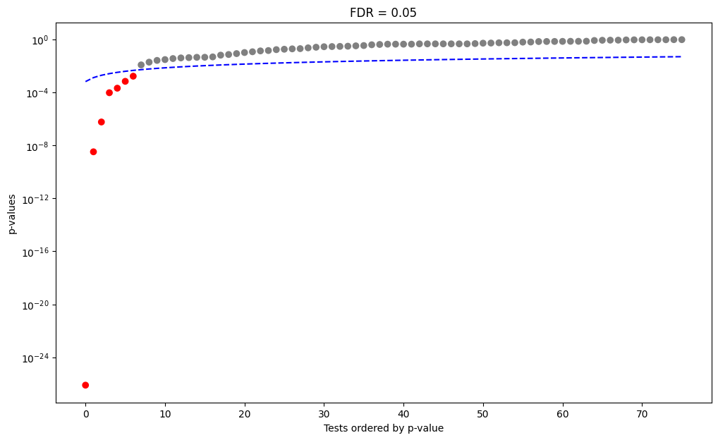

```
Alpha: 0.02623028159387944
Number of true discoveries: 10
```

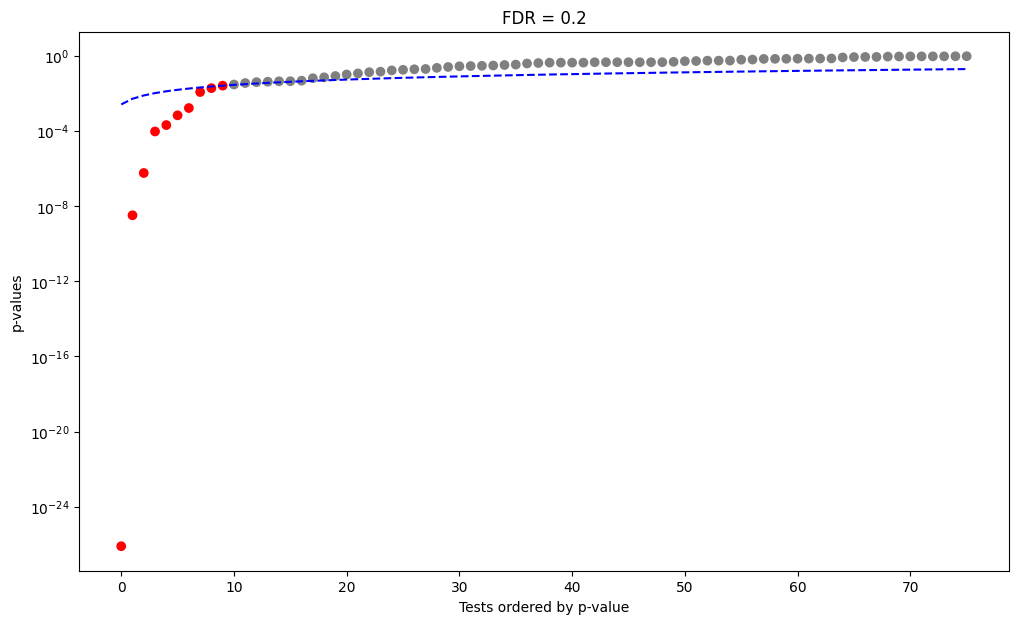

```
Alpha: 0.14563841964111326
Number of true discoveries: 24
```

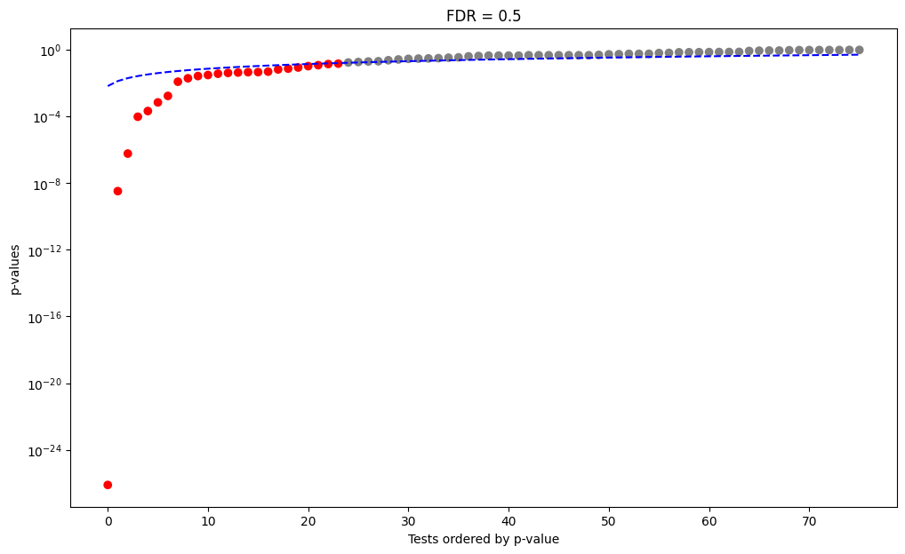

```
Alpha: 0.7365703406030824
Number of true discoveries: 64
```

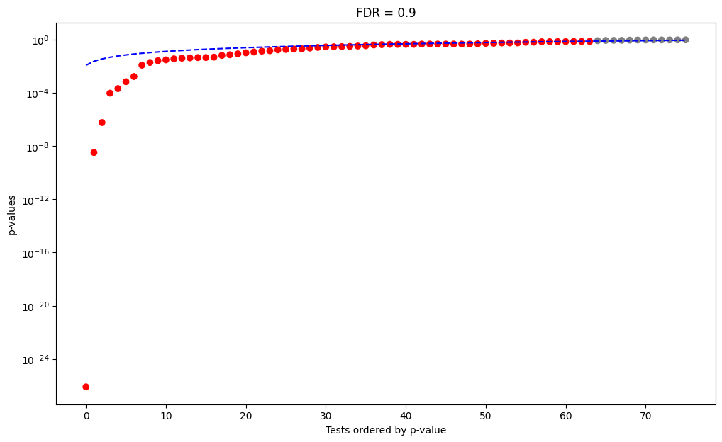

```python
alpha_threshold = fdr(pvals, 0.01, plotit=True)

alpha_threshold = fdr(pvals, 0.02, plotit=True)

alpha_threshold = fdr(pvals, 0.05, plotit=True)

alpha_threshold = fdr(pvals, 0.2, plotit=True)

alpha_threshold = fdr(pvals, 0.5, plotit=True)

alpha_threshold = fdr(pvals, 0.9, plotit=True)
```

If you apply the BH procedure at different q values, how do the results change?

Robustness of significant variables:

- At lower q-values, such as 0.01, where the number of true discoveries is only 6, these findings are typically more robust and reliable. A low q-value indicates a strict threshold for determining significance, suggesting that the variables identified under this threshold are highly likely to be genuinely impactful.
- Conversely, at higher q-values, for example, 0.9, where the number of true discoveries increases to 64, it suggests that many of these variables are identified as significant only under a much more lenient threshold. This increase could include variables whose significance is less certain or possibly coincidental. As a result, the confidence in these findings is comparatively lower, and they may not be as reliable or robust as those identified at lower q-values.

Hence, lower q values seem to showcase much more robustness when compared to higher q values.

# **7. Exploring Interaction Terms: (10pts, 5 pts for each) a. Expand your linear regression model by adding interaction terms. Create interaction terms between pairs of predictors (up to quadratic terms, i.e., terms of power two). You should include both original predictors and their interaction terms in your model. b. Briefly explain why interaction terms might be important in the context of predicting Estimated Shares Outstanding using fundamental financial metric**

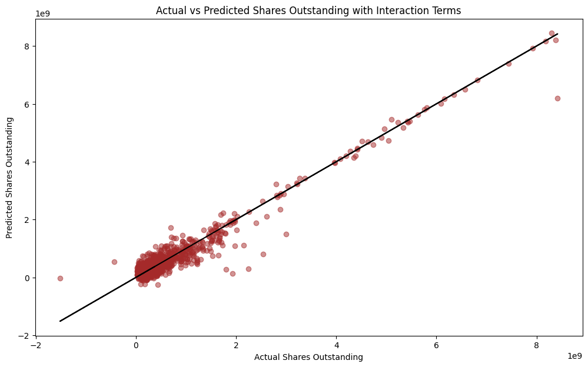

```
                                 OLS Regression Results
========================================================================================
Dep. Variable:     Estimated Shares Outstanding   R-squared:                       0.944
Model:                                      OLS   Adj. R-squared:                  0.926
Method:                           Least Squares   F-statistic:                     52.77
Date:                          Thu, 18 Jan 2024   Prob (F-statistic):               0.00
Time:                                  10:38:54   Log-Likelihood:                -26884.
No. Observations:                          1299   AIC:                         5.440e+04
Df Residuals:                               983   BIC:                         5.603e+04
Df Model:                                   315
Covariance Type:                      nonrobust
==============================================================================
                 coef    std err          t      P>|t|      [0.025      0.975]
------------------------------------------------------------------------------
x1            -0.0743      0.044     -1.673      0.095      -0.161       0.013
x2            -0.3653      0.258     -1.416      0.157      -0.871       0.141
x3            -0.1215      0.310     -0.392      0.695      -0.731       0.488
x4            -0.0163      0.006     -2.803      0.005      -0.028      -0.005
x5             0.0022      0.099      0.022      0.982      -0.191       0.196
x6             0.0586      0.021      2.842      0.005       0.018       0.099
x7         -7.408e-05      0.000     -0.178      0.858      -0.001       0.001
x8            -0.0317      0.058     -0.544      0.587      -0.146       0.083
x9             0.0983      0.398      0.247      0.805      -0.683       0.879
x10           -0.0074      0.050     -0.150      0.881      -0.105       0.090
x11           -0.0085      0.009     -0.934      0.351      -0.026       0.009
x12            0.0115      0.004      2.871      0.004       0.004       0.019
x13            0.2574      0.121      2.131      0.033       0.020       0.494
x14           -0.0467      0.060     -0.779      0.436      -0.164       0.071
x15            0.0190      0.151      0.125      0.900      -0.278       0.316
x16            0.8408      0.323      2.606      0.009       0.208       1.474
x17           -0.9485      0.331     -2.866      0.004      -1.598      -0.299
x18           -0.3764      0.121     -3.103      0.002      -0.614      -0.138
x19           -0.1130      0.041     -2.756      0.006      -0.193      -0.033
x20            0.0005      0.020      0.028      0.978      -0.038       0.039
x21            0.0554      0.029      1.935      0.053      -0.001       0.112
x22           -0.0027      0.001     -2.891      0.004      -0.005      -0.001
x23            0.0074      0.087      0.085      0.932      -0.163       0.178
x24            0.5392      0.338      1.596      0.111      -0.124       1.202
x25           -0.1713      0.045     -3.843      0.000      -0.259      -0.084
x26         3.944e-12   1.92e-12      2.057      0.040    1.82e-13    7.71e-12
```

[output cut: 320 more lines]

```
x347        2.342e-12   3.11e-12      0.753      0.452   -3.76e-12    8.45e-12
x348        2.577e-11   3.86e-11      0.668      0.504   -4.99e-11    1.01e-10
x349       -4.914e-11   2.25e-11     -2.180      0.029   -9.34e-11   -4.91e-12
x350       -6.419e-12   2.23e-12     -2.874      0.004   -1.08e-11   -2.04e-12
==============================================================================
Omnibus:                      715.525   Durbin-Watson:                   1.867
Prob(Omnibus):                  0.000   Jarque-Bera (JB):            19019.711
Skew:                           2.020   Prob(JB):                         0.00
Kurtosis:                      21.305   Cond. No.                     1.49e+16
==============================================================================

Notes:
[1] Standard Errors assume that the covariance matrix of the errors is correctly specified.
[2] The condition number is large, 1.49e+16. This might indicate that there are
strong multicollinearity or other numerical problems.
```

```python
#Part A
# Import Libraries
from sklearn.preprocessing import PolynomialFeatures
from statsmodels.api import OLS
import matplotlib.pyplot as plt

# Drop NA
df.dropna(inplace=True)

# Taking only the first 25 variables- as per the requiremnt
X_interaction = [
  'Accounts Payable', 'Accounts Receivable', 'Add\'l income/expense items',
  'After Tax ROE', 'Capital Expenditures', 'Capital Surplus', 'Cash Ratio',
  'Cash and Cash Equivalents', 'Changes in Inventories', 'Common Stocks',
  'Cost of Revenue', 'Current Ratio', 'Deferred Asset Charges',
  'Deferred Liability Charges', 'Depreciation', 'Earnings Before Interest and Tax',
  'Earnings Before Tax', 'Effect of Exchange Rate', 'Equity Earnings/Loss Unconsolidated Subsidiary',
  'Fixed Assets', 'Goodwill', 'Gross Margin', 'Gross Profit', 'Income Tax',
  'Intangible Assets'
]

Y_interaction = 'Estimated Shares Outstanding'

# Creating Data Frames
X = df[X_interaction]
y = df[Y_interaction]

poly = PolynomialFeatures(degree=2, interaction_only=False, include_bias=False) # check if its false or true here
X_transformed = poly.fit_transform(X)

# Fit the OLS model
model_int = OLS(y, X_transformed).fit()

# Predict
y_pred = model_int.predict(X_transformed)

# Plot
plt.figure(figsize=(12, 7))
plt.scatter(y, y_pred, alpha=0.5,color='brown')
plt.plot(y, y, color='black')
plt.title('Actual vs Predicted Shares Outstanding with Interaction Terms')
plt.xlabel('Actual Shares Outstanding')
plt.ylabel('Predicted Shares Outstanding')
plt.show()

# Print model summary
print(model_int.summary())
```

Part b: Importance of Interaction Terms in Predicting Estimated Shares Outstanding

- Interaction terms allow us to capture the combined effect of two variables, which are not additive in nature.
- Interactions may capture a significant relationship in explaining variability while each variable on its own may not be statistically significant
- This could provide us valuable inisghts on how pairs of variables affect the Estimated Shares Outstanding and provide us much more nuanced predictions
- For eg the combination of Long Term Debt and Cash Reserves might have a different impact on Estimated Shares Outstanding than when each of them would have had independently
- Hence, by incorporating interaction terms one can capture complex realtionships and improve the accuracy and reliability of the predictions for Estimated Shares Outstanding

# **8. Model Evaluation with Interaction Terms: (10pts, 5 pts for each) c. Evaluate the performance of this new model with interaction terms. Compare it with the performance of the original model without interaction terms using appropriate metrics. d. Discuss any significant changes in the model's performance or the coefficients of the predictors.**

Part C : Comparison of Original vs New Model

Overall the model with interactions(newer model) shows higher predictive accuracy

# **9. FDR Analysis with Interaction Terms: (10pts) a. Create a histogram of the p-values for the new model including interaction terms. Discuss any noticeable differences from the histogram you created for the original model.(3pts) b. Apply the Benjamini-Hochberg (BH) procedure to control the False Discovery Rate (FDR) with a q-value of 0.1. How many significant predictors are identified now, including both main effects and interaction effects? (5pts) c. Compare these results with those obtained from the original model. Discuss the impact of including interaction terms on the number of discoveries and the control of the FDR(2pts)**

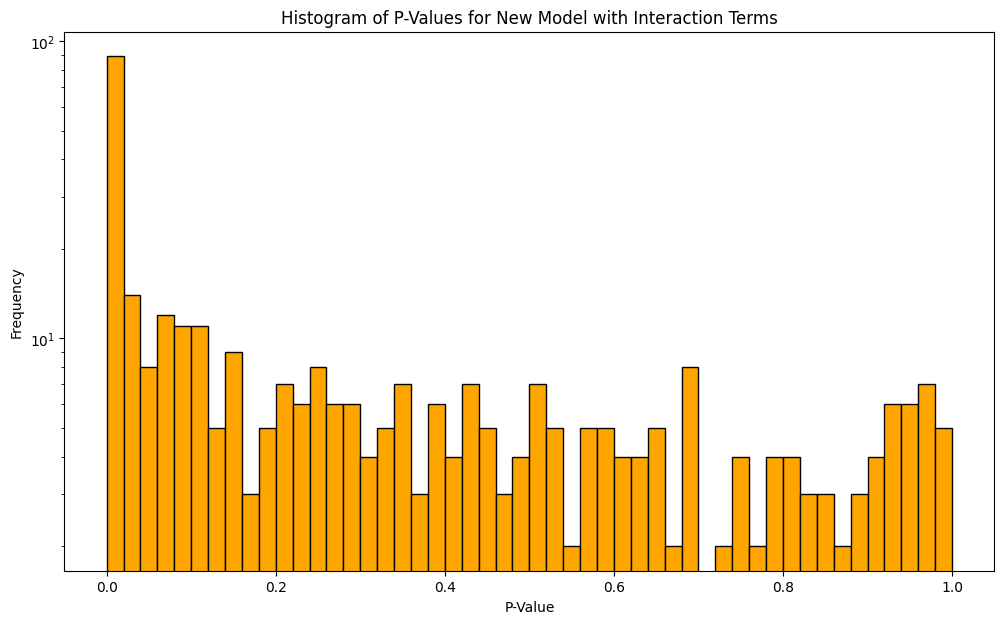

```
Skewness for all p-values: 0.7029121404746927
```

```python
#Part A
import matplotlib.pyplot as plt
import statsmodels.api as sm
from scipy.stats import skew

# Extract p-values from the summary of the new model with interaction terms
p_values_int = model_int.pvalues

# Create a histogram of p-values
plt.figure(figsize=(12, 7))
plt.hist(p_values_int, bins=50, color ='orange' ,  edgecolor='black')
plt.title("Histogram of P-Values for New Model with Interaction Terms")
plt.xlabel("P-Value")
plt.ylabel("Frequency")
plt.yscale('log')
plt.show()


# Skewness for the  of p-values
skewness_all = skew(p_values_int)
print(f"Skewness for all p-values: {skewness_all}")
```

```
Alpha: 0.021704123662679098
```

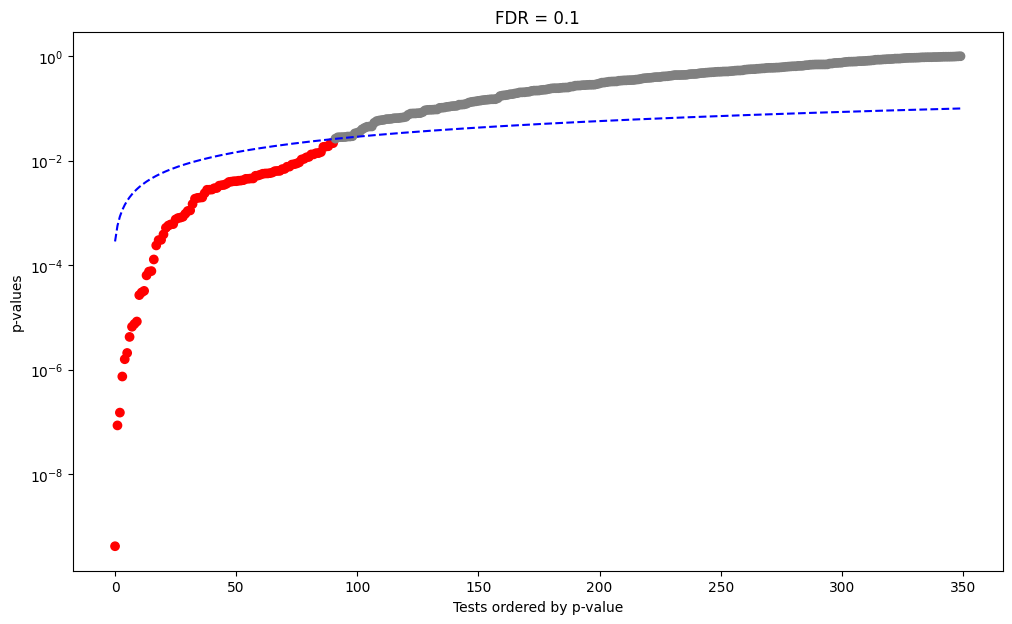

```
Number of significant predictors: 91
```

```python
#Part B
import numpy as np
import matplotlib.pyplot as plt

def fdr(p_values_int, q, plotit=True):
    # Remove NA values
    p_values_int = np.array(p_values_int)
    p_values_int = p_values_int[~np.isnan(p_values_int)]
    N = len(p_values_int)

    # Sort the p-values and calculate the FDR threshold
    sorted_pvals = np.sort(p_values_int)
    k = np.arange(1, N + 1)
    fdr_threshold = (q * k) / N

    # Find the last p-value that is below the FDR threshold
    below_threshold = sorted_pvals <= fdr_threshold
    max_index = np.max(np.where(below_threshold)) if np.any(below_threshold) else 0
    alpha = sorted_pvals[max_index]
    print(f"Alpha: {alpha}")


    # Optional plot
    if plotit:
        plt.figure(figsize=(12,7))
        plt.scatter(range(N), sorted_pvals, c=np.where(sorted_pvals <= alpha, 'red', 'grey'), marker='o')
        plt.yscale('log')
        plt.plot(range(N), fdr_threshold, linestyle='--', color='blue')
        plt.xlabel("Tests ordered by p-value")
        plt.ylabel("p-values")
        plt.title(f"FDR = {q}")
        plt.show()

    return alpha

# Apply the Benjamini-Hochberg (BH) procedure to control FDR with q = 0.1
alpha_threshold = fdr(p_values_int, 0.1)

# Count the number of significant predictors
num_significant_predictors = np.sum(p_values_int <= alpha_threshold)

print("Number of significant predictors:", num_significant_predictors)
```

The number of significant predictors identified now including main effects and interaction effects are - 91 when q =0.1

Part C:

- The number of discoveries increases drastically from 7(Original Model) to 91(Model with interaction Terms) with the same value of q=0.1 and with the inclusion of interaction terms. There was a signifcant increase in the number of variables being considered, however, the increase in discoveries is still proportionatly higher for the interaction model. This could be due to the fact that the interaction terms can capture additional variance in the data that main effects alone cannot, potentially revealing complex relationships between predictors and the response variable.
- The introduction of additional interaction terms, resulting in a higher number of tests, could increase the likelihood of false discoveries. This necessitates a more conservative approach to managing the False Discovery Rate (FDR), as the probability of encountering false positives escalates with the increased volume of tests performed.